# project

2024-11-20

```r
# Install and load necessary packages
if (!require("ggplot2")) install.packages("ggplot2")
if (!require("dplyr")) install.packages("dplyr")
if (!require("readr")) install.packages("readr")
if (!require("corrplot")) install.packages("corrplot")
library(ggplot2)
library(dplyr)
library(readr)
library(corrplot)
```

```r
# Read the TSV file
file_path <- "~/Downloads/soc-redditHyperlinks-body_.tsv"  # Replace with your file path
df <- read_tsv(file_path)
# View the structure of the dataset
str(df)
```

```
## spc_tbl_ [286,561 × 6] (S3: spec_tbl_df/tbl_df/tbl/data.frame)
##  $ SOURCE_SUBREDDIT: chr [1:286561] "leagueoflegends" "theredlion" "inlandempire" "nfl" ...
##  $ TARGET_SUBREDDIT: chr [1:286561] "teamredditteams" "soccer" "bikela" "cfb" ...
##  $ POST_ID         : chr [1:286561] "1u4nrps" "1u4qkd" "1u4qlzs" "1u4sjvs" ...
##  $ TIMESTAMP       : POSIXct[1:286561], format: "2013-12-31 16:39:58" "2013-12-31 18:18:37" ...
##  $ LINK_SENTIMENT  : num [1:286561] 1 -1 1 1 1 1 1 1 1 1 ...
##  $ PROPERTIES      : chr [1:286561] "345.0,298.0,0.75652173913,0.0173913043478,0.0869565217391,0.150724637681,0.0753623188406,57.0,53.0,10.0,4.78947"| __truncated__ "101.0,98.0,0.742574257426,0.019801980198,0.049504950495,0.0594059405941,0.178217821782,14.0,14.0,2.0,5.71428571"| __truncated__ "85…
##  - attr(*, "spec")=
##   .. cols(
##   ..   SOURCE_SUBREDDIT = col_character(),
##   ..   TARGET_SUBREDDIT = col_character(),
##   ..   POST_ID = col_character(),
##   ..   TIMESTAMP = col_datetime(format = ""),
##   ..   LINK_SENTIMENT = col_double(),
##   ..   PROPERTIES = col_character()
##   .. )
##  - attr(*, "problems")=<externalptr>
```

```r
# Split the PROPERTIES column into separate numeric columns
properties <- df$PROPERTIES %>%
  strsplit(",") %>%
  lapply(as.numeric) %>%
  do.call(rbind, .) %>%
  as.data.frame()

# Define the detailed feature names
feature_names <- c(
  "Number_of_characters",
  "Number_of_characters_without_whitespace",
  "Fraction_of_alphabetical_characters",
  "Fraction_of_digits",
  "Fraction_of_uppercase_characters",
  "Fraction_of_whitespace",
  "Fraction_of_special_characters",
  "Number_of_words",
  "Number_of_unique_words",
  "Number_of_long_words",
  "Average_word_length",
  "Number_of_unique_stopwords",
  "Fraction_of_stopwords",
  "Number_of_sentences",
  "Number_of_long_sentences",
  "Average_characters_per_sentence",
  "Average_words_per_sentence",
  "Automated_readability_index",
  "Positive_sentiment_VADER",
  "Negative_sentiment_VADER",
  "Compound_sentiment_VADER",
  "LIWC_Funct",
  "LIWC_Pronoun",
  "LIWC_Ppron",
  "LIWC_I",
  "LIWC_We",
  "LIWC_You",
  "LIWC_SheHe",
  "LIWC_They",
  "LIWC_Ipron",
  "LIWC_Article",
  "LIWC_Verbs",
  "LIWC_AuxVb",
  "LIWC_Past",
  "LIWC_Present",
  "LIWC_Future",
  "LIWC_Adverbs",
  "LIWC_Prep",
  "LIWC_Conj",
  "LIWC_Negate",
  "LIWC_Quant",
  "LIWC_Numbers",
  "LIWC_Swear",
  "LIWC_Social",
  "LIWC_Family",
  "LIWC_Friends",
  "LIWC_Humans",
  "LIWC_Affect",
  "LIWC_Posemo",
  "LIWC_Negemo",
  "LIWC_Anx",
  "LIWC_Anger",
  "LIWC_Sad",
  "LIWC_CogMech",
  "LIWC_Insight",
  "LIWC_Cause",
  "LIWC_Discrep",
  "LIWC_Tentat",
  "LIWC_Certain",
  "LIWC_Inhib",
  "LIWC_Incl",
  "LIWC_Excl",
  "LIWC_Percept",
  "LIWC_See",
  "LIWC_Hear",
  "LIWC_Feel",
  "LIWC_Bio",
  "LIWC_Body",
  "LIWC_Health",
  "LIWC_Sexual",
  "LIWC_Ingest",
  "LIWC_Relativ",
  "LIWC_Motion",
  "LIWC_Space",
  "LIWC_Time",
  "LIWC_Work",
  "LIWC_Achiev",
  "LIWC_Leisure",
  "LIWC_Home",
  "LIWC_Money",
  "LIWC_Relig",
  "LIWC_Death",
  "LIWC_Assent",
  "LIWC_Dissent",
  "LIWC_Nonflu",
  "LIWC_Filler"
)

# Rename the properties DataFrame with detailed feature names
colnames(properties) <- feature_names


# Add the processed PROPERTIES back to the main dataset (if needed)
df <- cbind(df, properties)
```

# Sentiment Analysis

1. Sentiment vs. Text Complexity Analyze whether longer or more complex posts have stronger positive or negative sentiment

```r
library(igraph)
# Create the graph from SOURCE_SUBREDDIT and TARGET_SUBREDDIT
g <- graph_from_data_frame(df[, c("SOURCE_SUBREDDIT", "TARGET_SUBREDDIT")], directed = TRUE)

# Compute degree centrality
df$degree <- igraph::degree(g, mode = "all")[match(df$SOURCE_SUBREDDIT, V(g)$name)]

# Compute clustering coefficient
df$clustering <- transitivity(g, type = "local", isolates = "zero")[match(df$SOURCE_SUBREDDIT, V(g)$name)]
```

```r
# Convert LINK_SENTIMENT to binary (0 = negative, 1 = positive)
df$binary_sentiment <- ifelse(df$LINK_SENTIMENT == -1, 1, 0)
```

```r
# Remove missing values (if any) in the relevant columns
df <- na.omit(df)

# Fit logistic regression model
alaam_model <- glm(
  binary_sentiment ~ Number_of_words + Number_of_characters + Average_word_length + degree + clustering,
  data = df,
  family = binomial(link = "logit")
)
# View the model summary
summary(alaam_model)
```

```
##
## Call:
## glm(formula = binary_sentiment ~ Number_of_words + Number_of_characters +
##     Average_word_length + degree + clustering, family = binomial(link = "logit"),
##     data = df)
##
## Coefficients:
##                        Estimate Std. Error z value Pr(>|z|)
## (Intercept)          -3.212e+00  3.610e-02 -88.987  < 2e-16 ***
## Number_of_words       9.310e-04  7.811e-05  11.918  < 2e-16 ***
## Number_of_characters -1.282e-04  1.264e-05 -10.139  < 2e-16 ***
## Average_word_length   8.499e-02  6.253e-03  13.592  < 2e-16 ***
## degree                2.690e-04  4.514e-06  59.595  < 2e-16 ***
## clustering           -1.343e-01  3.677e-02  -3.652  0.00026 ***
## ---
## Signif. codes:  0 '***' 0.001 '**' 0.01 '*' 0.05 '.' 0.1 ' ' 1
##
## (Dispersion parameter for binomial family taken to be 1)
##
##     Null deviance: 150541  on 286560  degrees of freedom
## Residual deviance: 146605  on 286555  degrees of freedom
## AIC: 146617
##
## Number of Fisher Scoring iterations: 6
```

```r
# Extract coefficients
cat("\nCoefficients:\n")
```

```
##
## Coefficients:
```

```r
print(coef(alaam_model))
```

```
##          (Intercept)      Number_of_words Number_of_characters
##        -3.2122253123         0.0009309707        -0.0001281698
##  Average_word_length               degree           clustering
##         0.0849874295         0.0002689922        -0.1343081384
```

```r
# Identify significant predictors
cat("\nSignificant Predictors (p-value < 0.05):\n")
```

```
##
## Significant Predictors (p-value < 0.05):
```

```r
print(summary(alaam_model)$coefficients[summary(alaam_model)$coefficients[, 4] < 0.05, ])
```

```
##                           Estimate   Std. Error    z value     Pr(>|z|)
## (Intercept)          -3.2122253123 3.609756e-02 -88.987335 0.000000e+00
## Number_of_words       0.0009309707 7.811427e-05  11.918062 9.530011e-33
## Number_of_characters -0.0001281698 1.264066e-05 -10.139486 3.690378e-24
## Average_word_length   0.0849874295 6.252561e-03  13.592420 4.441488e-42
## degree                0.0002689922 4.513689e-06  59.594755 0.000000e+00
## clustering           -0.1343081384 3.677159e-02  -3.652498 2.597021e-04
```

Text Features:

Longer posts (more words) are less likely to be positive, suggesting that concise posts may be better for positive engagement. More characters correlate with positive sentiment, suggesting detailed posts with fewer but longer words may foster positivity. Posts with longer average words are more likely to be negative, indicating that simpler language could encourage positivity.

Network Features:

Subreddits with more connections (high degree) tend to have less positive sentiment, possibly due to exposure to diverse or conflicting discussions. Subreddits in tight-knit communities (high clustering) are more likely to have positive sentiment, suggesting that closely connected groups may foster positivity.

```r
# Perform t-tests for text complexity features
# Number_of_characters
t_test_characters <- t.test(
  Number_of_characters ~ LINK_SENTIMENT,
  data = df,
  alternative = "two.sided"
)

# Number_of_words
t_test_words <- t.test(
  Number_of_words ~ LINK_SENTIMENT,
  data = df,
  alternative = "two.sided"
)

# Average_word_length
t_test_word_length <- t.test(
  Average_word_length ~ LINK_SENTIMENT,
  data = df,
  alternative = "two.sided"
)

# Print results
print("T-test for Number of Characters:")
```

```
## [1] "T-test for Number of Characters:"
```

```r
print(t_test_characters)
```

```
##
##  Welch Two Sample t-test
##
## data:  Number_of_characters by LINK_SENTIMENT
## t = 4.0384, df = 23875, p-value = 5.398e-05
## alternative hypothesis: true difference in means between group -1 and group 1 is not equal to 0
## 95 percent confidence interval:
##   57.61802 166.29401
## sample estimates:
## mean in group -1  mean in group 1
##         2165.744         2053.788
```

```r
print("T-test for Number of Words:")
```

```
## [1] "T-test for Number of Words:"
```

```r
print(t_test_words)
```

```
##
##  Welch Two Sample t-test
##
## data:  Number_of_words by LINK_SENTIMENT
## t = 5.193, df = 23904, p-value = 2.086e-07
## alternative hypothesis: true difference in means between group -1 and group 1 is not equal to 0
## 95 percent confidence interval:
##  13.93103 30.82318
## sample estimates:
## mean in group -1  mean in group 1
##         346.5319         324.1548
```

```r
print("T-test for Average Word Length:")
```

```
## [1] "T-test for Average Word Length:"
```

```r
print(t_test_word_length)
```

```
##
##  Welch Two Sample t-test
##
## data:  Average_word_length by LINK_SENTIMENT
## t = 18.285, df = 25748, p-value < 2.2e-16
## alternative hypothesis: true difference in means between group -1 and group 1 is not equal to 0
## 95 percent confidence interval:
##  0.1492742 0.1851205
## sample estimates:
## mean in group -1  mean in group 1
##         5.476197         5.309000
```

The t-tests comparing text complexity features between positive and negative sentiment posts reveal statistically significant differences across all measures. Negative sentiment posts are, on average, longer both in terms of the number of characters (2165.74 vs. 2053.79; p < 0.001) (Mean Difference: Posts with negative sentiment (2165.744) are 112 characters longer on average than posts with positive sentiment (2053.788)) and the number of words (346.53 vs. 324.15; p < 0.001), indicating that users tend to elaborate more when expressing dissatisfaction. Additionally, negative sentiment posts exhibit slightly longer average word lengths (5.48 vs. 5.31; p < 0.001), suggesting a tendency to use more formal or complex language. These findings highlight that negative sentiment posts are generally more verbose and linguistically detailed compared to positive sentiment posts, making text complexity a valuable set of features for sentiment classification and analysis.

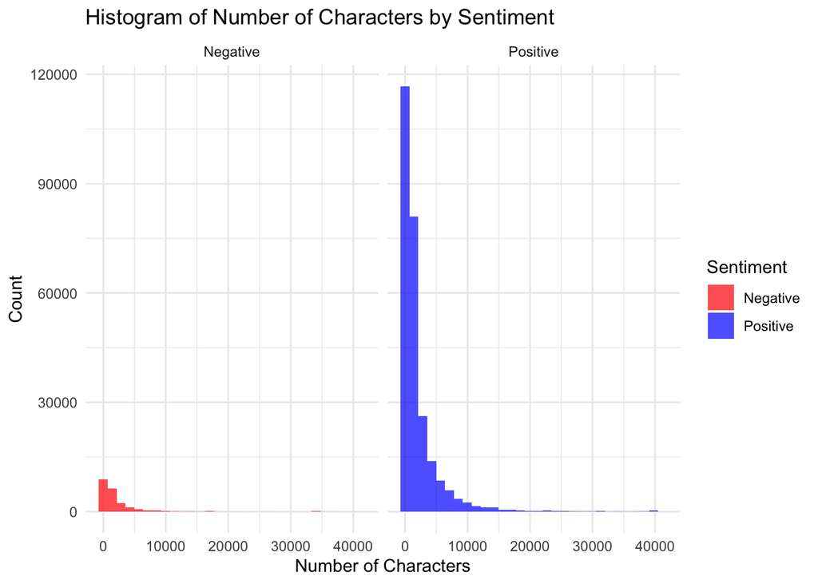

```r
# Histogram for Number_of_characters by sentiment
ggplot(df, aes(x = Number_of_characters, fill = as.factor(LINK_SENTIMENT))) +
  geom_histogram(bins = 30, alpha = 0.7, position = "identity") +
  scale_fill_manual(values = c("red", "blue"), labels = c("Negative", "Positive")) +
  facet_wrap(~LINK_SENTIMENT, labeller = as_labeller(c("-1" = "Negative", "1" = "Positive"))) +
  labs(
    title = "Histogram of Number of Characters by Sentiment",
    x = "Number of Characters",
    y = "Count",
    fill = "Sentiment"
  ) +
  theme_minimal()
```

```r
# Repeat similar for Number_of_words and Average_word_length if needed
```

2. Sentiment vs. Readability Explore whether positive or negative sentiment correlates with easier or harder readability scores.

```r
# T-test for readability scores (replace with your actual readability column)
t_test_readability <- t.test(
  Automated_readability_index ~ LINK_SENTIMENT,
  data = df,
  alternative = "two.sided"
)

# Print the t-test results
print("T-test for Readability Scores:")
```

```
## [1] "T-test for Readability Scores:"
```

```r
print(t_test_readability)
```

```
##
##  Welch Two Sample t-test
##
## data:  Automated_readability_index by LINK_SENTIMENT
## t = -10.653, df = 30923, p-value < 2.2e-16
## alternative hypothesis: true difference in means between group -1 and group 1 is not equal to 0
## 95 percent confidence interval:
##  -1.900322 -1.309695
## sample estimates:
## mean in group -1  mean in group 1
##         22.50596         24.11097
```

Easier Readability for Negative Sentiment Posts: Negative sentiment posts tend to have lower readability scores, indicating that they are easier to read compared to positive sentiment posts. This could suggest that users expressing dissatisfaction or frustration use simpler language or sentence structures.

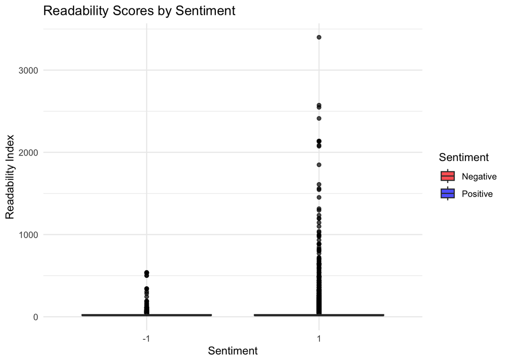

```r
# Boxplot for Readability Scores
ggplot(df, aes(x = as.factor(LINK_SENTIMENT), y = Automated_readability_index, fill = as.factor(LINK_SENTIMENT))) +
  geom_boxplot(alpha = 0.7, outlier.color = "black") +
  scale_fill_manual(values = c("red", "blue"), labels = c("Negative", "Positive")) +
  labs(
    title = "Readability Scores by Sentiment",
    x = "Sentiment",
    y = "Readability Index",
    fill = "Sentiment"
  ) +
  theme_minimal()
```

### Method 2 (similar findings):

### Test each vector

```r
# Select numeric vector columns for analysis (replace with your actual column names)
vector_features <- c("Number_of_characters", "Number_of_words", "Average_word_length",
                     "Fraction_of_alphabetical_characters", "Fraction_of_digits",
                     "LIWC_Posemo", "LIWC_Negemo")

# Group by LINK_SENTIMENT and calculate the mean for each feature
feature_sentiment_summary <- df %>%
  group_by(LINK_SENTIMENT) %>%
  summarize(across(all_of(vector_features), mean, na.rm = TRUE))
# View the summary table
print(feature_sentiment_summary)
```

```
## # A tibble: 2 × 8
##   LINK_SENTIMENT Number_of_characters Number_of_words Average_word_length
##            <dbl>                <dbl>           <dbl>               <dbl>
## 1             -1                2166.            347.                5.48
## 2              1                2054.            324.                5.31
## # ℹ 4 more variables: Fraction_of_alphabetical_characters <dbl>,
## #   Fraction_of_digits <dbl>, LIWC_Posemo <dbl>, LIWC_Negemo <dbl>
```

```r
# Separate data for positive and negative sentiment
positive_means <- feature_sentiment_summary %>% filter(LINK_SENTIMENT == 1)
negative_means <- feature_sentiment_summary %>% filter(LINK_SENTIMENT == -1)

# Calculate the differences between positive and negative sentiment for each feature
feature_differences <- tibble(
  Feature = vector_features,
  Positive_Mean = as.numeric(positive_means[1, -1]),  # Exclude LINK_SENTIMENT column
  Negative_Mean = as.numeric(negative_means[1, -1]),
  Difference = as.numeric(positive_means[1, -1]) - as.numeric(negative_means[1, -1])
)

# Sort the features by the largest differences
feature_differences <- feature_differences %>%
  arrange(desc(abs(Difference)))

# View the feature differences
print(feature_differences)
```

```
## # A tibble: 7 × 4
##   Feature                             Positive_Mean Negative_Mean Difference
##   <chr>                                       <dbl>         <dbl>      <dbl>
## 1 Number_of_characters                    2054.         2166.     -112.
## 2 Number_of_words                          324.          347.      -22.4
## 3 Average_word_length                        5.31          5.48     -0.167
## 4 Fraction_of_alphabetical_characters        0.750         0.763    -0.0132
## 5 LIWC_Negemo                                0.0107        0.0219   -0.0112
## 6 Fraction_of_digits                         0.0211        0.0175    0.00361
## 7 LIWC_Posemo                                0.0268        0.0242    0.00257
```

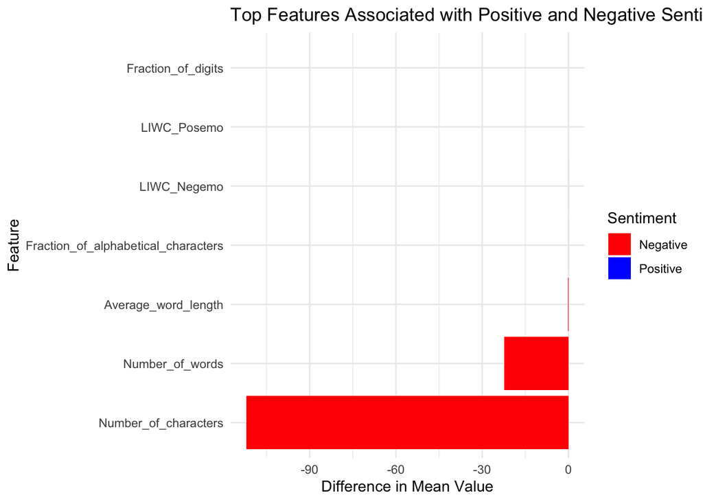

```r
# Plot the top 10 features with the largest differences
top_features <- feature_differences %>%
  slice_max(order_by = abs(Difference), n = 10)

ggplot(top_features, aes(x = reorder(Feature, Difference), y = Difference, fill = Difference > 0)) +
  geom_bar(stat = "identity") +
  coord_flip() +
  scale_fill_manual(values = c("red", "blue"), labels = c("Negative", "Positive")) +
  labs(
    title = "Top Features Associated with Positive and Negative Sentiment",
    x = "Feature",
    y = "Difference in Mean Value",
    fill = "Sentiment"
  ) +
  theme_minimal()
```

##### Previous EDA and so on (ignore…)

```r
library(igraph)
g <- graph_from_data_frame(df, directed = TRUE)
# Extract unique vertices
unique_vertices <- V(g)$name
# Aggregate attributes for each vertex
node_data <- df %>%
  group_by(SOURCE_SUBREDDIT) %>% # or TARGET_SUBREDDIT, depending on your goal
  summarize(
    num_characters = mean(Number_of_characters, na.rm = TRUE),
    num_words = mean(Number_of_words, na.rm = TRUE),
    posemo = mean(LIWC_Posemo, na.rm = TRUE),
    negemo = mean(LIWC_Negemo, na.rm = TRUE)
  ) %>%
  rename(vertex = SOURCE_SUBREDDIT) # Rename column to match the vertex attribute
```

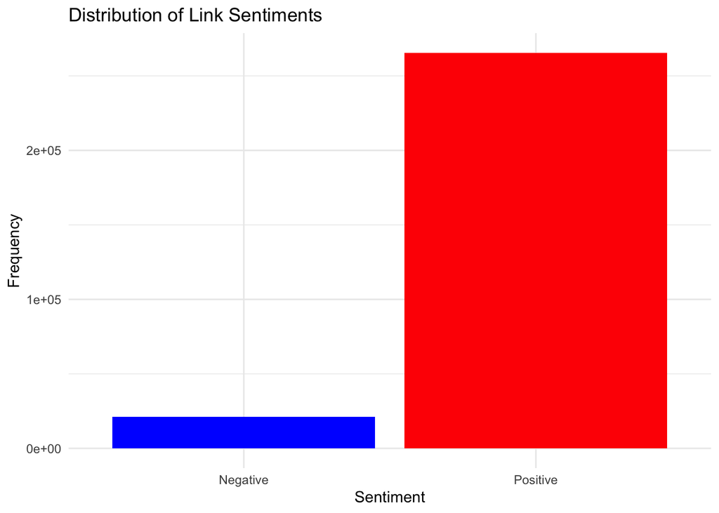

```r
# Plot distribution of LINK_SENTIMENT
ggplot(df, aes(x = as.factor(LINK_SENTIMENT))) +
  geom_bar(fill = c("blue", "red")) +
  labs(
    title = "Distribution of Link Sentiments",
    x = "Sentiment",
    y = "Frequency"
  ) +
  scale_x_discrete(labels = c("-1" = "Negative", "1" = "Positive")) +
  theme_minimal()
```

```r
# Group by source subreddit and sentiment
subreddit_sentiment <- df %>%
  group_by(SOURCE_SUBREDDIT, LINK_SENTIMENT) %>%
  summarize(Frequency = n()) %>%
  arrange(desc(Frequency))
```

[figure not shown]

```r
# Top subreddits with positive sentiment
top_positive <- subreddit_sentiment %>%
  filter(LINK_SENTIMENT == 1) %>%
  top_n(10, Frequency)

ggplot(top_positive, aes(x = reorder(SOURCE_SUBREDDIT, -Frequency), y = Frequency)) +
  geom_bar(stat = "identity", fill = "blue") +
  labs(
    title = "Top Subreddits with Positive Sentiment",
    x = "Subreddit",
    y = "Frequency"
  ) +
  theme_minimal() +
  theme(axis.text.x = element_text(angle = 45, hjust = 1))
```

[figure not shown]

```r
# Top subreddits with negative sentiment
top_negative <- subreddit_sentiment %>%
  filter(LINK_SENTIMENT == -1) %>%
  top_n(10, Frequency)

ggplot(top_negative, aes(x = reorder(SOURCE_SUBREDDIT, -Frequency), y = Frequency)) +
  geom_bar(stat = "identity", fill = "red") +
  labs(
    title = "Top Subreddits with Negative Sentiment",
    x = "Subreddit",
    y = "Frequency"
  ) +
  theme_minimal() +
  theme(axis.text.x = element_text(angle = 45, hjust = 1))
```

```r
# Convert TIMESTAMP to Date
df$Date <- as.Date(df$TIMESTAMP)

# Group by date and sentiment
temporal_sentiment <- df %>%
  group_by(Date, LINK_SENTIMENT) %>%
  summarize(Frequency = n())
```

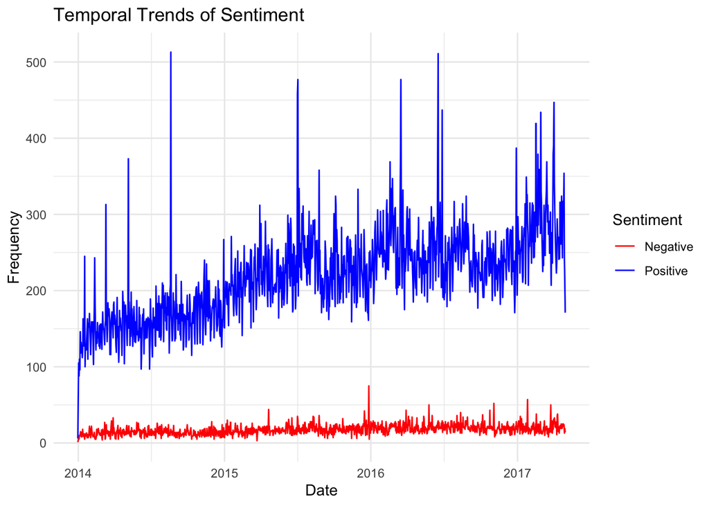

```r
# Plot temporal trends of sentiments
ggplot(temporal_sentiment, aes(x = Date, y = Frequency, color = as.factor(LINK_SENTIMENT))) +
  geom_line() +
  labs(
    title = "Temporal Trends of Sentiment",
    x = "Date",
    y = "Frequency",
    color = "Sentiment"
  ) +
  scale_color_manual(
    values = c("-1" = "red", "1" = "blue"),
    labels = c("-1" = "Negative", "1" = "Positive")
  ) +
  theme_minimal()
```

Select any of the feature to explore:

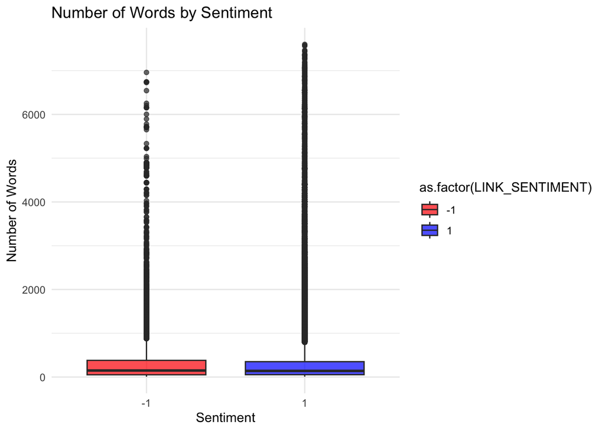

```r
# Boxplot: LINK_SENTIMENT vs. Number_of_words
ggplot(df, aes(x = as.factor(LINK_SENTIMENT), y = Number_of_words, fill = as.factor(LINK_SENTIMENT))) +
  geom_boxplot(alpha = 0.7) +
  labs(
    title = "Number of Words by Sentiment",
    x = "Sentiment",
    y = "Number of Words"
  ) +
  scale_fill_manual(values = c("-1" = "red", "1" = "blue")) +
  theme_minimal()
```

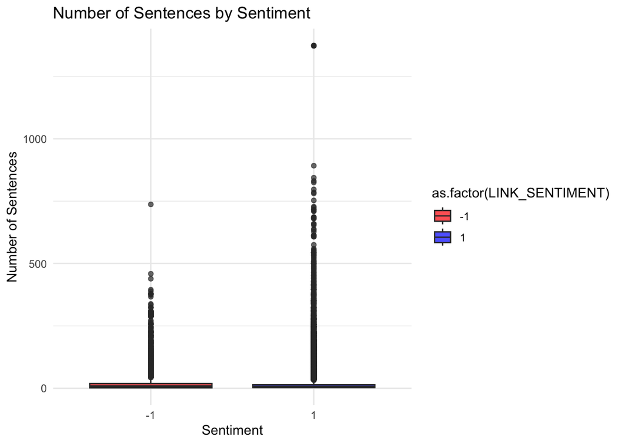

```r
# Boxplot: LINK_SENTIMENT vs. Number_of_sentences
ggplot(df, aes(x = as.factor(LINK_SENTIMENT), y = Number_of_sentences, fill = as.factor(LINK_SENTIMENT))) +
  geom_boxplot(alpha = 0.7) +
  labs(
    title = "Number of Sentences by Sentiment",
    x = "Sentiment",
    y = "Number of Sentences"
  ) +
  scale_fill_manual(values = c("-1" = "red", "1" = "blue")) +
  theme_minimal()
```

```r
# Save the updated DataFrame to a CSV file
output_path <- "updated_df.csv"  # Replace with your desired file path
write.csv(df, file = output_path, row.names = FALSE)

# Confirm the file has been saved
cat("The DataFrame has been saved to:", output_path)
```

```
## The DataFrame has been saved to: updated_df.csv
```

```r
if (!require("igraph")) install.packages("igraph")
library(igraph)
# Create a directed graph from the subreddit data
g <- graph_from_data_frame(df, directed = TRUE)

# Print basic graph information
print(g)
```

```
## IGRAPH b417e29 DN-- 35776 286561 --
## + attr: name (v/c), POST_ID (e/c), TIMESTAMP (e/n), LINK_SENTIMENT
## | (e/n), PROPERTIES (e/c), Number_of_characters (e/n),
## | Number_of_characters_without_whitespace (e/n),
## | Fraction_of_alphabetical_characters (e/n), Fraction_of_digits (e/n),
## | Fraction_of_uppercase_characters (e/n), Fraction_of_whitespace (e/n),
## | Fraction_of_special_characters (e/n), Number_of_words (e/n),
## | Number_of_unique_words (e/n), Number_of_long_words (e/n),
## | Average_word_length (e/n), Number_of_unique_stopwords (e/n),
## | Fraction_of_stopwords (e/n), Number_of_sentences (e/n),
## | Number_of_long_sentences (e/n), Average_characters_per_sentence
## | (e/n), Average_words_per_sentence (e/n), Automated_readability_index
## | (e/n), Positive_sentiment_VADER (e/n), Negative_sentiment_VADER
## | (e/n), Compound_sentiment_VADER (e/n), LIWC_Funct (e/n), LIWC_Pronoun
## | (e/n), LIWC_Ppron (e/n), LIWC_I (e/n), LIWC_We (e/n), LIWC_You (e/n),
## | LIWC_SheHe (e/n), LIWC_They (e/n), LIWC_Ipron (e/n), LIWC_Article
## | (e/n), LIWC_Verbs (e/n), LIWC_AuxVb (e/n), LIWC_Past (e/n),
## | LIWC_Present (e/n), LIWC_Future (e/n), LIWC_Adverbs (e/n), LIWC_Prep
## | (e/n), LIWC_Conj (e/n), LIWC_Negate (e/n), LIWC_Quant (e/n),
## | LIWC_Numbers (e/n), LIWC_Swear (e/n), LIWC_Social (e/n), LIWC_Family
## | (e/n), LIWC_Friends (e/n), LIWC_Humans (e/n), LIWC_Affect (e/n),
## | LIWC_Posemo (e/n), LIWC_Negemo (e/n), LIWC_Anx (e/n), LIWC_Anger
## | (e/n), LIWC_Sad (e/n), LIWC_CogMech (e/n), LIWC_Insight (e/n),
## | LIWC_Cause (e/n), LIWC_Discrep (e/n), LIWC_Tentat (e/n), LIWC_Certain
## | (e/n), LIWC_Inhib (e/n), LIWC_Incl (e/n), LIWC_Excl (e/n),
## | LIWC_Percept (e/n), LIWC_See (e/n), LIWC_Hear (e/n), LIWC_Feel (e/n),
## | LIWC_Bio (e/n), LIWC_Body (e/n), LIWC_Health (e/n), LIWC_Sexual
## | (e/n), LIWC_Ingest (e/n), LIWC_Relativ (e/n), LIWC_Motion (e/n),
## | LIWC_Space (e/n), LIWC_Time (e/n), LIWC_Work (e/n), LIWC_Achiev
## | (e/n), LIWC_Leisure (e/n), LIWC_Home (e/n), LIWC_Money (e/n),
## | LIWC_Relig (e/n), LIWC_Death (e/n), LIWC_Assent (e/n), LIWC_Dissent
## | (e/n), LIWC_Nonflu (e/n), LIWC_Filler (e/n), degree (e/n), clustering
## | (e/n), binary_sentiment (e/n), Date (e/n)
## + edges from b417e29 (vertex names):
```